# Natural Language Processing Project

Alex (Oleksiy) Varfolomiyev

December 27, 2015

## Synopsis

People are spending an increasing amount of time on their mobile devices as 2015 reports show. Enhancement of the manipulation/typing on the mobile devices is of a tremendous use. SwiftKey company, builds a smart keyboard that makes it easier for people to type on their mobile devices. One cornerstone of their smart keyboard is predictive text models. The current project focuses on the analysis of text data and natural language processing.

We are provided with the text data from a corpus called HC Corpora http://corpora.heliohost.org. We perform text mining and exploratory analysis of the course data set understanding the distribution of words and relationship between the words in the corpora.

## Reading Data

```r
require(tm)
require(stringi)
require(SnowballC)
require(RWeka)
require(ggplot2)
require(wordcloud)
require(parallel)
```

```r
# Download text files
if(!file.exists("final")) {
   fileURL <- "http://d396qusza40orc.cloudfront.net/dsscapstone/dataset/Coursera-SwiftKey.zip"
   fileName <- "Coursera-SwiftKey.zip"
   download.file(fileURL, fileName)
   dateDownloaded <- date()
   dateDownloaded
   unzip(zipfile = dataDestination)
}

if(!exists("blg")) {
  fileName <- file("./final/en_US/en_US.blogs.txt", "rt")
  blg <- readLines(fileName, encoding="UTF-8")
  close(fileName)
}

if(!exists("nws")) {
  fileName <- file("./final/en_US/en_US.news.txt", "rt")
  nws <- readLines(fileName, encoding="UTF-8")
  close(fileName)
}

if(!exists("twit")) {
  fileName <- file("./final/en_US/en_US.twitter.txt", "rt")
  twit <- readLines(fileName, encoding="UTF-8")
  close(fileName)
}

if(!exists("DataSummaryStats")) {
  DataSummaryStats <- data.frame(
    dataSource = c("blogs","news","twitter"),
    Size = c(
      file.info("./final/en_US/en_US.blogs.txt")$size,
      file.info("./final/en_US/en_US.news.txt")$size,
      file.info("./final/en_US/en_US.twitter.txt")$size),
    Lines = c(length(blg), length(nws), length(twit)),
    Words = c(sum(stri_count_words(blg)),
              sum(stri_count_words(nws)),
              sum(stri_count_words(twit)))
  )
}
knitr::kable(DataSummaryStats)
```

| dataSource | Size | Lines | Words |
| --- | --- | --- | --- |
| blogs | 210159817 | 899288 | 37541795 |
| news | 205811889 | 1010242 | 34762303 |
| twitter | 167105311 | 2360148 | 30092865 |

## Data Processing

```r
# Sample data
#if(!exists("dat")) {
  set.seed(111)
  smplFraction <- .01
  smplBlg <- sample(blg, smplFraction*length(blg))
  rm(blg)

  smplNws <- sample(nws, smplFraction*length(nws))
  rm(nws)

  smplTwit <- sample(twit, smplFraction*length(twit))
  rm(twit)

  # Combine all texts to Corpus
  dat <- c(smplBlg, smplNws, smplTwit)
  dat <- VCorpus(VectorSource(dat))

  # Data Cleaning
  myCluster <- makeCluster(detectCores(), type = "FORK") # FORK will not work on Windows

  rmSpecialChars <- content_transformer(function(x, pattern) gsub(pattern, " ", x, perl = T))

  dat <- tm_map(dat, removePunctuation)
  dat <- tm_map(dat, removeNumbers)
  #dat <- tm_map(dat, removeWords, stopwords("english"))
  profanities <- readLines("./final/en_US/profanities.txt")
  dat <- tm_map(dat, removeWords, profanities)
  dat <- tm_map(dat, rmSpecialChars, "/|@|\\|#")
  dat <- tm_map(dat, stripWhitespace)
  dat <- tm_map(dat, content_transformer(tolower))
  #dot <- tm_map(dat, stemDocument)
  save(dat, file = "./data/en_US/en_US.sample.Rda")

  stopCluster(myCluster)

#}

# N-grams init
if(!exists("tdm")) {
  options(mc.cores=1)
  unigramTokenizer <- function(x) NGramTokenizer(x, control = Weka_control(min = 1, max = 1))
  bigramTokenizer <- function(x) NGramTokenizer(x, control = Weka_control(min = 2, max = 2))
  trigramTokenizer <- function(x) NGramTokenizer(x, control = Weka_control(min = 3, max = 3))
  fourgramTokenizer <- function(x) NGramTokenizer(x, control = Weka_control(min = 4, max = 4))

  # Term Document Matrices init
  tdm <- TermDocumentMatrix(dat)
  pSparsity <- .99
  tdm <- removeSparseTerms(tdm, pSparsity)
  save(tdm, file = "./data/en_US/en_US.tdm.Rda")

  tdm2 <- TermDocumentMatrix(dat, control = list(tokenize = bigramTokenizer))
  #tdm2 <- removeSparseTerms(tdm2a, 0.999)
  save(tdm2, file = "./data/en_US/en_US.tdm2.Rda")

  tdm3 <- TermDocumentMatrix(dat, control = list(tokenize = trigramTokenizer))
  #tdm3 <- removeSparseTerms(tdm3, 0.999)
  save(tdm3, file = "./data/en_US/en_US.tdm3.Rda")

#   tdm4 <- TermDocumentMatrix(dat, control = list(tokenize = fourgramTokenizer))
#   #tdm4 <- removeSparseTerms(tdm4, 0.999)
#   save(tdm4, file = "./data/en_US/en_US.tdm4.Rda")
}
```

## Exploratory Data Analysis

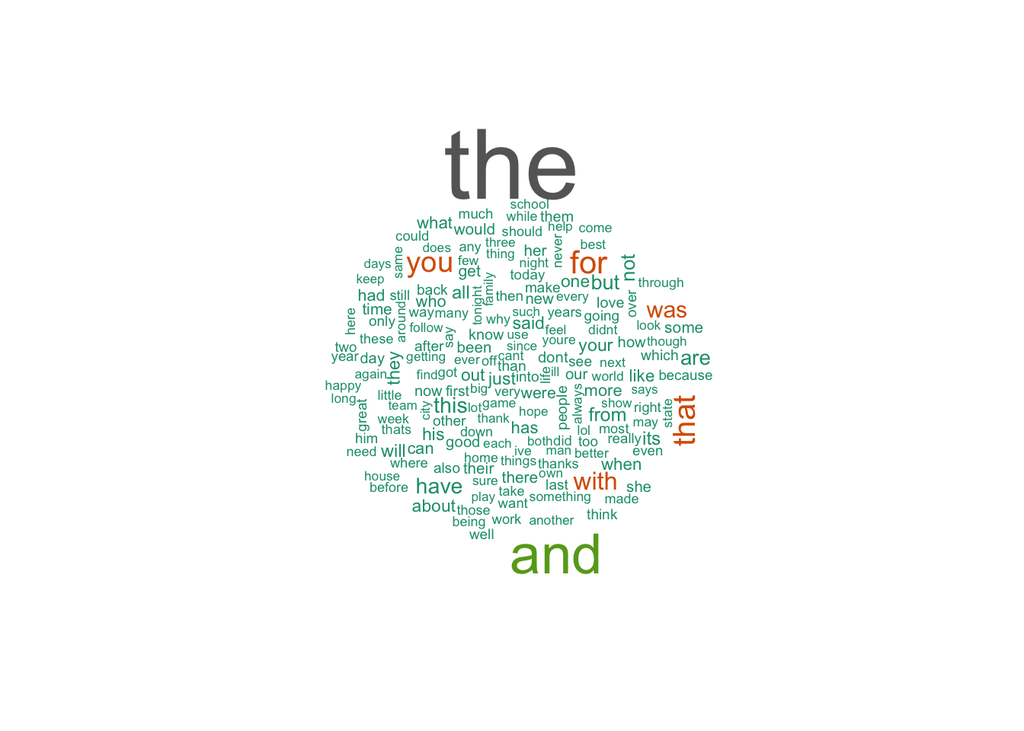

```r
# Plot most frequent entries
freq <- sort(rowSums(as.matrix(tdm)), decreasing = TRUE)
wrdFreqMatrix <- data.frame(word = names(freq), frequency = freq)
saveRDS(wrdFreqMatrix, file = "./data/en_US/unigramsSample.Rds")

set.seed(1)
wordcloud(names(freq), freq, min.freq=500, colors=brewer.pal(8, "Dark2"))
```

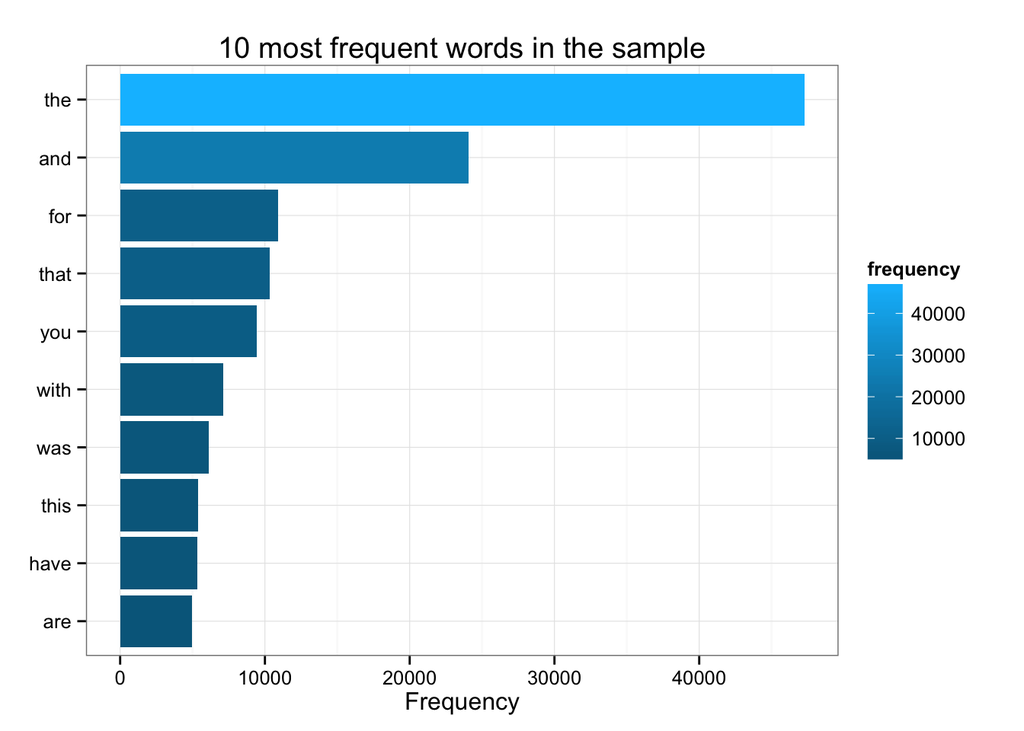

```r
wrdFreqPlot <- ggplot(head(wrdFreqMatrix, 10),
                      aes(x = reorder(word, frequency), y = frequency, fill=frequency)) +
  geom_bar(stat="identity") +
  scale_fill_gradient( low = "deepskyblue4", high = "deepskyblue") +
  theme_bw() +
  coord_flip() +
  theme(axis.title.y = element_blank()) +
  labs(x = "word", y = "Frequency", title = "10 most frequent words in the sample")

print(wrdFreqPlot)
```

```r
knitr::kable(head(wrdFreqMatrix, 10))
```

|  | word | frequency |
| --- | --- | --- |
| the | the | 47263 |
| and | and | 24058 |
| for | for | 10927 |
| that | that | 10330 |
| you | you | 9435 |
| with | with | 7109 |
| was | was | 6103 |
| this | this | 5378 |
| have | have | 5329 |
| are | are | 4943 |

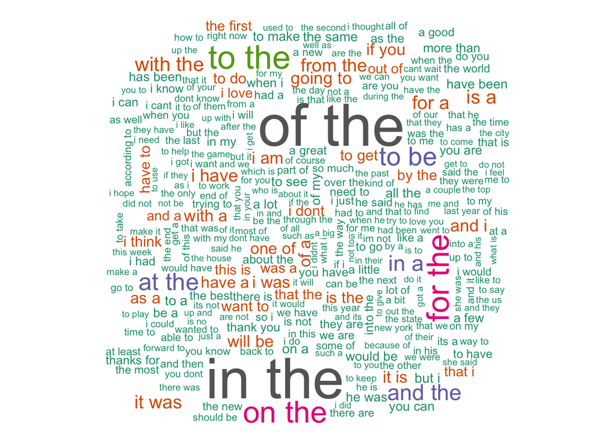

```r
# Plot most frequent bigrams
tdm2_freq <- slam::row_sums(tdm2, na.rm = T)
freq <- sort(tdm2_freq, decreasing = TRUE)
wrd2FreqMatrix <- data.frame(bigram = names(freq), frequency = freq)
saveRDS(wrdFreqMatrix, file = "./data/en_US/bigramsSample.Rds")

set.seed(1)
wordcloud(names(freq), freq, min.freq=150, colors=brewer.pal(8, "Dark2"))
```

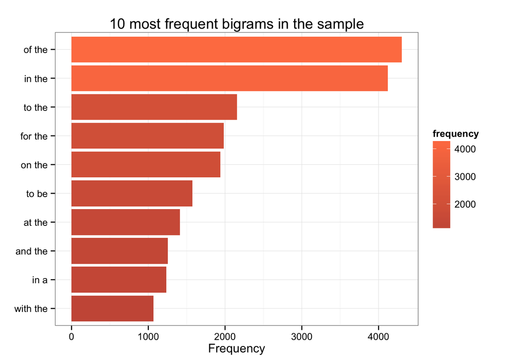

```r
wrd2FreqPlot <- ggplot(head(wrd2FreqMatrix, 10),
                      aes(x = reorder(bigram, frequency), y = frequency, fill=frequency)) +
  geom_bar(stat="identity") +
  scale_fill_gradient(low = "coral3", high = "coral") +
  theme_bw() +
  coord_flip() +
  theme(axis.title.y = element_blank()) +
  labs(x = "word", y = "Frequency", title = "10 most frequent bigrams in the sample")

print(wrd2FreqPlot)
```

```r
knitr::kable(head(wrd2FreqMatrix, 10))
```

|  | bigram | frequency |
| --- | --- | --- |
| of the | of the | 4304 |
| in the | in the | 4122 |
| to the | to the | 2156 |
| for the | for the | 1983 |
| on the | on the | 1937 |
| to be | to be | 1574 |
| at the | at the | 1410 |
| and the | and the | 1255 |
| in a | in a | 1234 |
| with the | with the | 1069 |

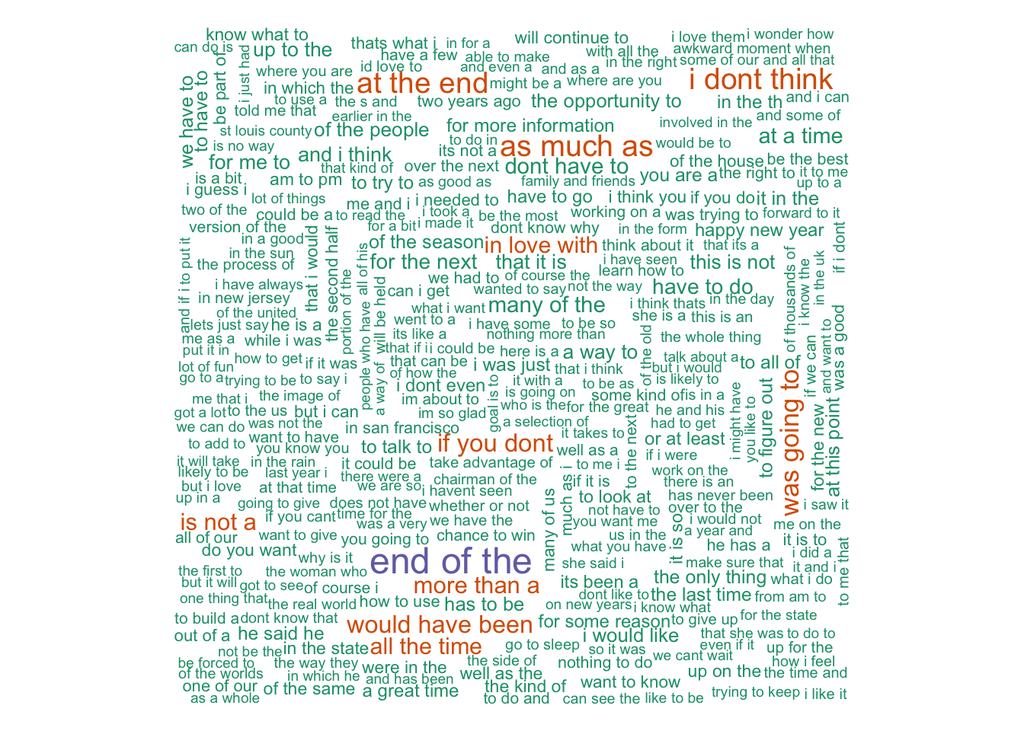

```r
# Plot most frequent trigrams
tdm3_freq <- slam::row_sums(tdm3, na.rm = T)
freq <- sort(tdm3_freq, decreasing = TRUE)
wrd3FreqMatrix <- data.frame(trigram = names(freq), frequency = freq)
saveRDS(wrdFreqMatrix, file = "./data/en_US/trigramsSample.Rds")

set.seed(1)
wordcloud(names(freq), freq, min.freq=10, colors=brewer.pal(8, "Dark2"))
```

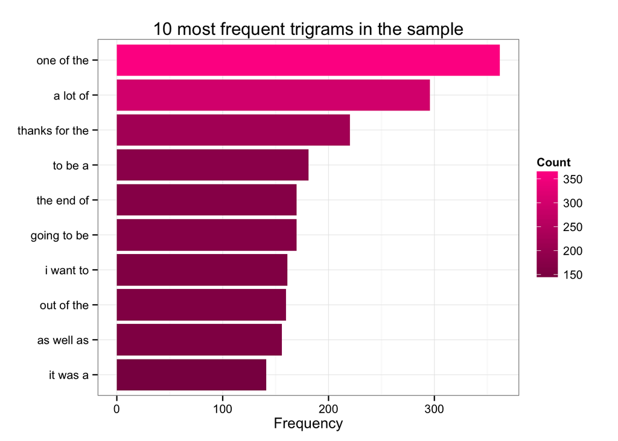

```r
wrd3FreqPlot <- ggplot(head(wrd3FreqMatrix, 10),
                       aes(x = reorder(trigram, frequency), y = frequency, fill=frequency)) +
  geom_bar(stat="identity") +
  scale_fill_gradient("Count", low = "deeppink4", high = "deeppink1") +
  theme_bw() +
  coord_flip() +
  theme(axis.title.y = element_blank()) +
  labs(x = "word", y = "Frequency", title = "10 most frequent trigrams in the sample")

print(wrd3FreqPlot)
```

```r
knitr::kable(head(wrd3FreqMatrix, 10))
```

|  | trigram | frequency |
| --- | --- | --- |
| one of the | one of the | 362 |
| a lot of | a lot of | 296 |
| thanks for the | thanks for the | 220 |
| to be a | to be a | 181 |
| going to be | going to be | 170 |
| the end of | the end of | 170 |
| i want to | i want to | 161 |
| out of the | out of the | 160 |
| as well as | as well as | 156 |
| it was a | it was a | 141 |

## Summary

Shiny App under development will take typed text as an input and provide a few predictions of the next word in the typed text for the chosen algorithm and smoothing method.

Model can be evaluated for efficiency and accuracy using timing software to evaluate the computational complexity of the model. Evaluation of the model accuracy using different metrics like perplexity, accuracy at the first word, second word, and third word, resampling. Alternative, more advanced libraries can be used for the text mining and processing to improve the efficiencty of the real-time Shiny App model prediction.